# Tutorium_07_05_2021_PreProj_Part1

dzt

5/6/2021

The first part of the project.

Thema:

-Data import

-Exploratory data analysis -datashape transform(pivot_long()) -distribution check(ggplot(),facet_wrap()) -logarithm transformation(log()) -missing value check(skim(),drop()) -correlation check (cor()) -outliers check(boxplot)

-some stories found in the data

# 1 Daten import

```r
library(readr)
research <- read_csv("https://raw.githubusercontent.com/sebastiansauer/willingness-vaccination-covid19/main/data/d3.csv")
```

# 2 Check the missing number

```r
library(skimr)
skim(research)
```

Data summary

| Name | research |
| --- | --- |
| Number of rows | 164 |
| Number of columns | 23 |
| _______________________ |  |
| Column type frequency: |  |
| character | 3 |
| numeric | 20 |
| ________________________ |  |
| Group variables | None |

**Variable type: character**

| skim_variable | n_missing | complete_rate | min | max | empty | n_unique | whitespace |
| --- | --- | --- | --- | --- | --- | --- | --- |
| timestamp | 0 | 1.00 | 19 | 19 | 0 | 164 | 0 |
| sex | 0 | 1.00 | 4 | 6 | 0 | 3 | 0 |
| comments | 157 | 0.04 | 9 | 295 | 0 | 6 | 0 |

**Variable type: numeric**

| skim_variable | n_missing | complete_rate | mean | sd | p0 | p25 | p50 | p75 | p100 | hist |
| --- | --- | --- | --- | --- | --- | --- | --- | --- | --- | --- |
| willingness | 0 | 1.00 | 8.10 | 2.69 | 1.0 | 7.00 | 9.0 | 10.0 | 10 | ▁▁▁▂▇ |
| health | 0 | 1.00 | 9.30 | 1.28 | 3.0 | 9.00 | 10.0 | 10.0 | 10 | ▁▁▁▁▇ |
| fear | 0 | 1.00 | 4.73 | 2.40 | 1.0 | 3.00 | 5.0 | 7.0 | 10 | ▆▆▇▆▂ |
| cases | 0 | 1.00 | 5.10 | 5.63 | 0.0 | 2.00 | 4.0 | 6.0 | 50 | ▇▁▁▁▁ |
| extra1 | 0 | 1.00 | 3.20 | 1.11 | 1.0 | 2.00 | 3.0 | 4.0 | 5 | ▂▅▇▇▃ |
| agree1 | 0 | 1.00 | 3.13 | 1.09 | 1.0 | 2.00 | 3.0 | 4.0 | 5 | ▂▆▇▆▃ |
| cons1 | 0 | 1.00 | 3.07 | 1.23 | 1.0 | 2.00 | 3.0 | 4.0 | 5 | ▃▇▇▇▅ |
| neuro1 | 0 | 1.00 | 3.09 | 1.03 | 1.0 | 2.00 | 3.0 | 4.0 | 5 | ▁▇▇▇▂ |
| open1 | 0 | 1.00 | 3.74 | 1.19 | 1.0 | 3.00 | 4.0 | 5.0 | 5 | ▁▃▅▇▇ |
| extra2 | 0 | 1.00 | 3.55 | 1.08 | 1.0 | 3.00 | 4.0 | 4.0 | 5 | ▁▃▇▇▅ |
| agree2 | 0 | 1.00 | 3.11 | 1.11 | 1.0 | 2.00 | 3.0 | 4.0 | 5 | ▂▆▇▇▂ |
| cons2 | 0 | 1.00 | 3.79 | 0.80 | 2.0 | 3.00 | 4.0 | 4.0 | 5 | ▁▃▁▇▂ |
| neuro2 | 0 | 1.00 | 3.03 | 1.09 | 1.0 | 2.00 | 3.0 | 4.0 | 5 | ▂▇▆▇▂ |
| open2 | 0 | 1.00 | 3.96 | 0.97 | 1.0 | 3.00 | 4.0 | 5.0 | 5 | ▁▂▃▇▆ |
| age | 2 | 0.99 | 20.67 | 2.18 | 18.0 | 19.00 | 20.0 | 21.0 | 29 | ▇▂▂▁▁ |
| extra | 0 | 1.00 | 3.37 | 1.00 | 1.0 | 2.88 | 3.5 | 4.0 | 5 | ▁▅▅▇▅ |
| agree | 0 | 1.00 | 3.12 | 0.87 | 1.5 | 2.50 | 3.0 | 3.5 | 5 | ▃▂▇▂▂ |
| neuro | 0 | 1.00 | 3.06 | 0.90 | 1.0 | 2.50 | 3.0 | 3.5 | 5 | ▂▇▅▇▂ |
| cons | 0 | 1.00 | 3.43 | 0.86 | 1.5 | 3.00 | 3.5 | 4.0 | 5 | ▂▂▇▃▃ |
| open | 0 | 1.00 | 3.85 | 0.91 | 1.0 | 3.00 | 4.0 | 4.5 | 5 | ▁▂▃▇▇ |

2 age missing

```r
library(dplyr)
research <- select(research, -extra,-agree,-neuro,-cons,-open)
research
```

```
## # A tibble: 164 x 18
##    timestamp     willingness health  fear cases extra1 agree1 cons1 neuro1 open1
##    <chr>               <dbl>  <dbl> <dbl> <dbl>  <dbl>  <dbl> <dbl>  <dbl> <dbl>
##  1 23/04/2021 1…          10      9     5     1      2      2     3      2     4
##  2 23/04/2021 1…          10     10     7     7      4      3     5      4     3
##  3 23/04/2021 1…           3     10     2     0      3      5     4      3     5
##  4 23/04/2021 1…           7     10     6    10      1      3     3      4     2
##  5 23/04/2021 1…          10     10     5     8      2      3     3      3     3
##  6 23/04/2021 1…          10     10     3     4      4      3     4      4     5
##  7 23/04/2021 1…           9      9     7     3      3      5     2      3     4
##  8 23/04/2021 1…          10      9     5     5      3      4     4      3     4
##  9 23/04/2021 1…           9      9     5     3      4      3     3      3     5
## 10 23/04/2021 1…           5     10     1     4      4      4     5      4     5
## # … with 154 more rows, and 8 more variables: extra2 <dbl>, agree2 <dbl>,
## #   cons2 <dbl>, neuro2 <dbl>, open2 <dbl>, age <dbl>, sex <chr>,
## #   comments <chr>
```

# 3 Drop cases with missing values in age

```r
library(tidyr)
researchnona1 <-
research %>%drop_na(age)

skim(researchnona1)
```

Data summary

| Name | researchnona1 |
| --- | --- |
| Number of rows | 162 |
| Number of columns | 18 |
| _______________________ |  |
| Column type frequency: |  |
| character | 3 |
| numeric | 15 |
| ________________________ |  |
| Group variables | None |

**Variable type: character**

| skim_variable | n_missing | complete_rate | min | max | empty | n_unique | whitespace |
| --- | --- | --- | --- | --- | --- | --- | --- |
| timestamp | 0 | 1.00 | 19 | 19 | 0 | 162 | 0 |
| sex | 0 | 1.00 | 4 | 6 | 0 | 3 | 0 |
| comments | 155 | 0.04 | 9 | 295 | 0 | 6 | 0 |

**Variable type: numeric**

| skim_variable | n_missing | complete_rate | mean | sd | p0 | p25 | p50 | p75 | p100 | hist |
| --- | --- | --- | --- | --- | --- | --- | --- | --- | --- | --- |
| willingness | 0 | 1 | 8.09 | 2.71 | 1 | 7 | 9 | 10 | 10 | ▁▁▁▂▇ |
| health | 0 | 1 | 9.30 | 1.29 | 3 | 9 | 10 | 10 | 10 | ▁▁▁▁▇ |
| fear | 0 | 1 | 4.76 | 2.40 | 1 | 3 | 5 | 7 | 10 | ▆▆▇▆▂ |
| cases | 0 | 1 | 5.12 | 5.66 | 0 | 2 | 4 | 6 | 50 | ▇▁▁▁▁ |
| extra1 | 0 | 1 | 3.20 | 1.11 | 1 | 2 | 3 | 4 | 5 | ▂▅▇▇▃ |
| agree1 | 0 | 1 | 3.14 | 1.08 | 1 | 2 | 3 | 4 | 5 | ▁▆▇▆▃ |
| cons1 | 0 | 1 | 3.08 | 1.23 | 1 | 2 | 3 | 4 | 5 | ▃▇▇▇▅ |
| neuro1 | 0 | 1 | 3.09 | 1.04 | 1 | 2 | 3 | 4 | 5 | ▁▇▇▇▂ |
| open1 | 0 | 1 | 3.73 | 1.19 | 1 | 3 | 4 | 5 | 5 | ▁▃▅▇▇ |
| extra2 | 0 | 1 | 3.56 | 1.08 | 1 | 3 | 4 | 4 | 5 | ▁▃▇▇▅ |
| agree2 | 0 | 1 | 3.10 | 1.12 | 1 | 2 | 3 | 4 | 5 | ▂▆▇▇▂ |
| cons2 | 0 | 1 | 3.79 | 0.80 | 2 | 3 | 4 | 4 | 5 | ▁▃▁▇▂ |
| neuro2 | 0 | 1 | 3.02 | 1.10 | 1 | 2 | 3 | 4 | 5 | ▂▇▆▇▂ |
| open2 | 0 | 1 | 3.95 | 0.97 | 1 | 3 | 4 | 5 | 5 | ▁▂▃▇▆ |
| age | 0 | 1 | 20.67 | 2.18 | 18 | 19 | 20 | 21 | 29 | ▇▂▂▁▁ |

```r
researchnona1
```

```
## # A tibble: 162 x 18
##    timestamp     willingness health  fear cases extra1 agree1 cons1 neuro1 open1
##    <chr>               <dbl>  <dbl> <dbl> <dbl>  <dbl>  <dbl> <dbl>  <dbl> <dbl>
##  1 23/04/2021 1…          10      9     5     1      2      2     3      2     4
##  2 23/04/2021 1…          10     10     7     7      4      3     5      4     3
##  3 23/04/2021 1…           3     10     2     0      3      5     4      3     5
##  4 23/04/2021 1…           7     10     6    10      1      3     3      4     2
##  5 23/04/2021 1…          10     10     5     8      2      3     3      3     3
##  6 23/04/2021 1…          10     10     3     4      4      3     4      4     5
##  7 23/04/2021 1…           9      9     7     3      3      5     2      3     4
##  8 23/04/2021 1…          10      9     5     5      3      4     4      3     4
##  9 23/04/2021 1…           9      9     5     3      4      3     3      3     5
## 10 23/04/2021 1…           5     10     1     4      4      4     5      4     5
## # … with 152 more rows, and 8 more variables: extra2 <dbl>, agree2 <dbl>,
## #   cons2 <dbl>, neuro2 <dbl>, open2 <dbl>, age <dbl>, sex <chr>,
## #   comments <chr>
```

# 4 Distribution of output “willingess” variablen

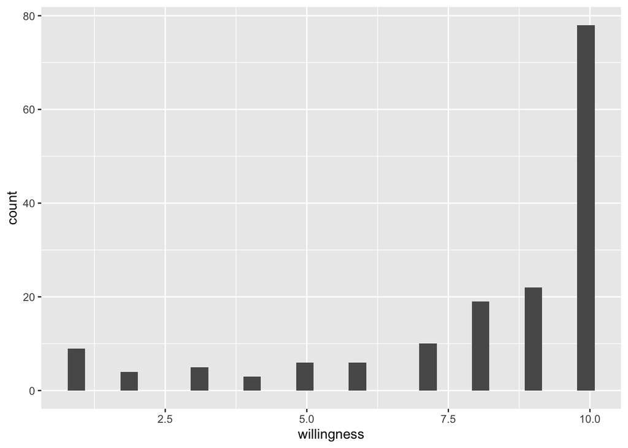

```r
library(ggplot2)
researchnona1%>%
ggplot(aes(x=willingness)) + geom_histogram()
```

# 5 Reshaping the data(pivot_long)

```r
library(tidyverse)
researchreshaping <-
select_if(researchnona1,is.numeric) %>%  # select only numbers
  pivot_longer(everything(), names_to = "variable")
  # everything() is a convenient shorthand to pivot all variables. pivot_longer(everything()) https://jhudatascience.org/tidyversecourse/wrangle-data.html

researchreshaping
```

```
## # A tibble: 2,430 x 2
##    variable    value
##    <chr>       <dbl>
##  1 willingness    10
##  2 health          9
##  3 fear            5
##  4 cases           1
##  5 extra1          2
##  6 agree1          2
##  7 cons1           3
##  8 neuro1          2
##  9 open1           4
## 10 extra2          1
## # … with 2,420 more rows
```

# 6 Distribution of all predictors

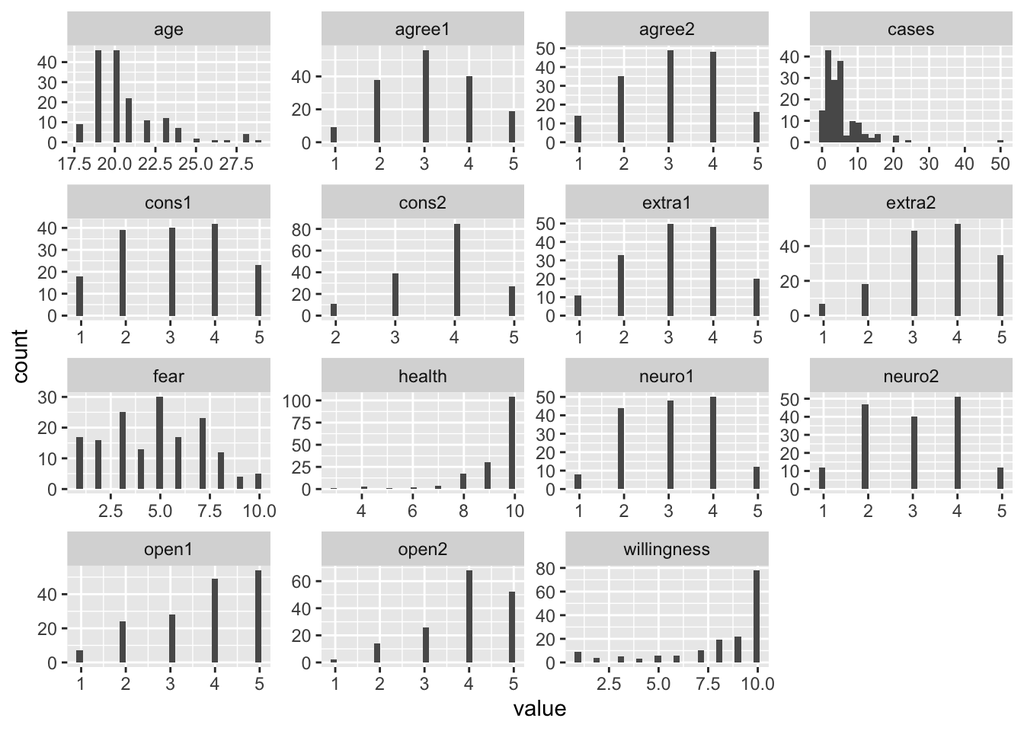

```r
  ggplot(researchreshaping,aes(x = value)) +
  geom_histogram() +
  facet_wrap(~ variable, scales = "free")
```

For both the cases variables, the right-skew makes the lower end of the x-axis hard. To make patterns in the data more interpretable and for helping to meet the assumptions of inferential statistics, then need to be transformed

# 7 How to transform data to normal distribution in R?

https://www.datanovia.com/en/lessons/transform-data-to-normal-distribution-in-r/ https://moderndive.com/11-thinking-with-data.html#house-prices-EDA-I 11.3

first try log transformation in a situation where the dependent variable starts to increase more rapidly with increasing independent variable values

log10(x) for positively skewed data, log10(max(x+1) - x) for negatively skewed data

# 8 Transform (via logarithm)

```r
researchnona1<- mutate(researchnona1,cases_log10=log10(age))
researchnona1
```

```
## # A tibble: 162 x 19
##    timestamp     willingness health  fear cases extra1 agree1 cons1 neuro1 open1
##    <chr>               <dbl>  <dbl> <dbl> <dbl>  <dbl>  <dbl> <dbl>  <dbl> <dbl>
##  1 23/04/2021 1…          10      9     5     1      2      2     3      2     4
##  2 23/04/2021 1…          10     10     7     7      4      3     5      4     3
##  3 23/04/2021 1…           3     10     2     0      3      5     4      3     5
##  4 23/04/2021 1…           7     10     6    10      1      3     3      4     2
##  5 23/04/2021 1…          10     10     5     8      2      3     3      3     3
##  6 23/04/2021 1…          10     10     3     4      4      3     4      4     5
##  7 23/04/2021 1…           9      9     7     3      3      5     2      3     4
##  8 23/04/2021 1…          10      9     5     5      3      4     4      3     4
##  9 23/04/2021 1…           9      9     5     3      4      3     3      3     5
## 10 23/04/2021 1…           5     10     1     4      4      4     5      4     5
## # … with 152 more rows, and 9 more variables: extra2 <dbl>, agree2 <dbl>,
## #   cons2 <dbl>, neuro2 <dbl>, open2 <dbl>, age <dbl>, sex <chr>,
## #   comments <chr>, cases_log10 <dbl>
```

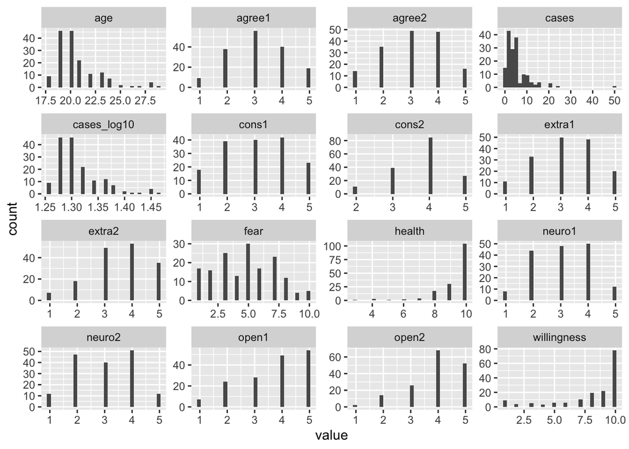

```r
select_if(researchnona1,is.numeric) %>%  # select only numbers
  pivot_longer(everything(), names_to = "variable") %>%
  ggplot(aes(x = value)) +
  geom_histogram() +
  facet_wrap(~ variable, scales = "free")
```

# 9 Check outliers

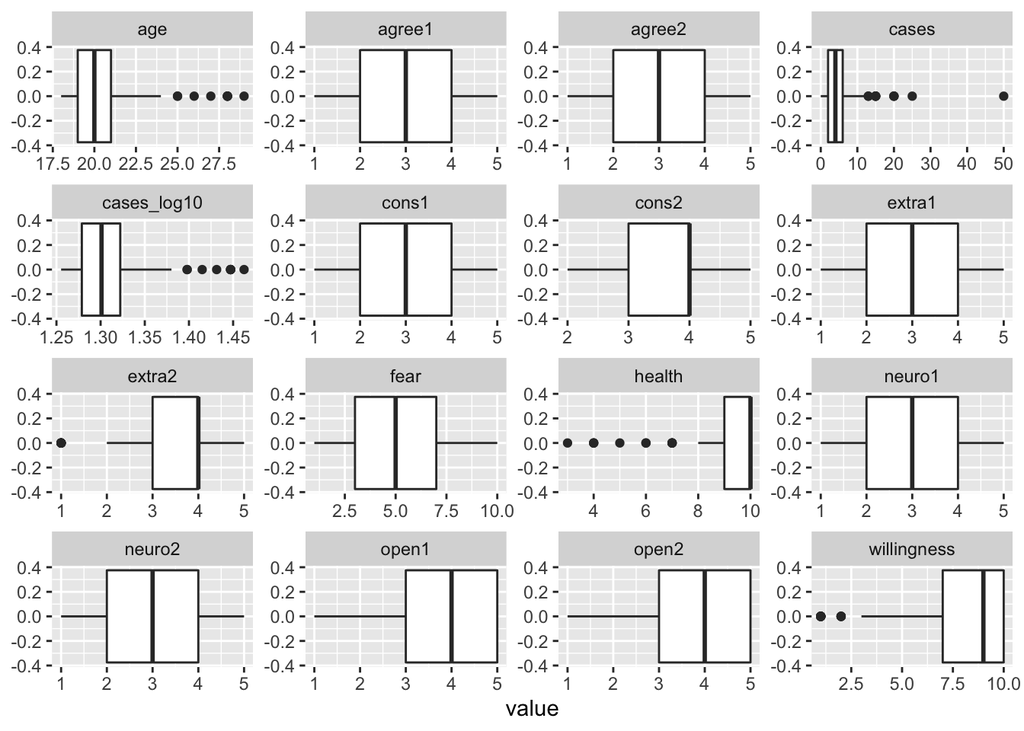

```r
select_if(researchnona1,is.numeric) %>%  # select only numbers
  pivot_longer(everything(), names_to = "variable") %>%
  ggplot(aes(x = value)) +
  geom_boxplot() +
  facet_wrap(~ variable, scales = "free")
```

# 10 Find correlation (cormatrix)

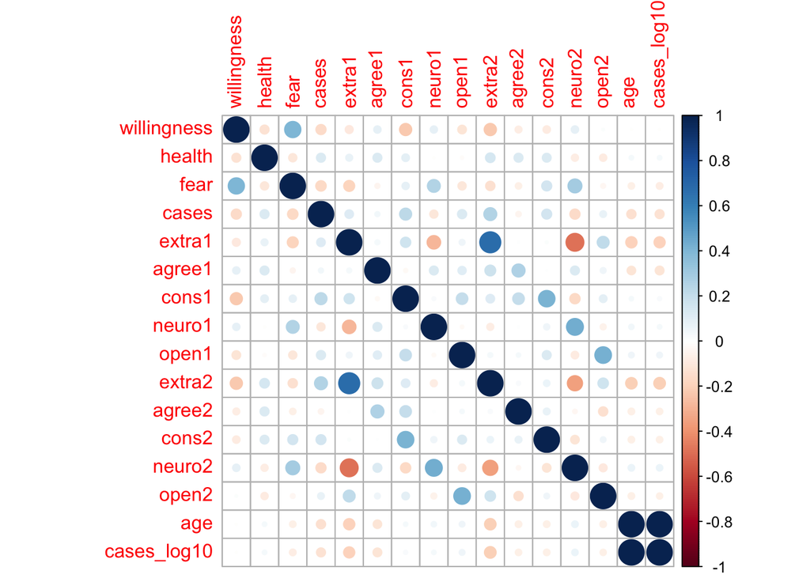

```r
library(corrplot)
researchnona1 <- select_if(researchnona1, is.numeric)
corrplot(cor(researchnona1), method = "circle")
```

cases_log10 and age have a strong positive correlation

```r
cor(researchnona1)
```

```
##              willingness       health        fear       cases       extra1
## willingness  1.000000000 -0.124856369  0.40435323 -0.15806757 -0.098979096
## health      -0.124856369  1.000000000 -0.10534112  0.12543484  0.074742032
## fear         0.404353234 -0.105341123  1.00000000 -0.16775180 -0.184535996
## cases       -0.158067571  0.125434844 -0.16775180  1.00000000  0.113879453
## extra1      -0.098979096  0.074742032 -0.18453600  0.11387945  1.000000000
## agree1       0.083274045  0.122805477 -0.04014795  0.04014894  0.039044522
## cons1       -0.225867402  0.090567532  0.08234458  0.22068393  0.160738049
## neuro1       0.081518005 -0.005337664  0.25347626 -0.10345998 -0.280135271
## open1       -0.115880501 -0.017178044 -0.10488798  0.12873133  0.055115004
## extra2      -0.229200551  0.142830732 -0.13450791  0.25538260  0.675937905
## agree2      -0.074881739  0.124774091 -0.06466569 -0.04712478  0.007695131
## cons2       -0.086330366  0.120952858  0.15495874  0.15241855  0.013485605
## neuro2       0.085035091 -0.079806851  0.29732971 -0.15850745 -0.488658386
## open2        0.011097462 -0.082535091 -0.03717518  0.07119564  0.217038235
## age         -0.004554317  0.033076792 -0.06641912 -0.13100871 -0.194758294
## cases_log10 -0.005202808  0.033193561 -0.07039529 -0.12494013 -0.190722266
##                   agree1       cons1       neuro1       open1      extra2
## willingness  0.083274045 -0.22586740  0.081518005 -0.11588050 -0.22920055
## health       0.122805477  0.09056753 -0.005337664 -0.01717804  0.14283073
## fear        -0.040147949  0.08234458  0.253476263 -0.10488798 -0.13450791
## cases        0.040148937  0.22068393 -0.103459979  0.12873133  0.25538260
## extra1       0.039044522  0.16073805 -0.280135271  0.05511500  0.67593790
## agree1       1.000000000 -0.02699232  0.122934397  0.10539854  0.17947458
## cons1       -0.026992323  1.00000000  0.023751780  0.20472447  0.11535958
## neuro1       0.122934397  0.02375178  1.000000000 -0.02150859 -0.07694703
## open1        0.105398536  0.20472447 -0.021508588  1.00000000  0.03926190
## extra2       0.179474575  0.11535958 -0.076947031  0.03926190  1.00000000
## agree2       0.261316888  0.20597662  0.008210052  0.03029933  0.02803309
## cons2        0.004450591  0.41492008  0.059543502  0.12347631  0.06544959
## neuro2       0.123180839 -0.16240003  0.435170648 -0.08975878 -0.35232110
## open2        0.053963608  0.09173479 -0.057513553  0.42278357  0.16883042
## age         -0.112583039  0.03080361  0.045751852  0.05159866 -0.20182853
## cases_log10 -0.119134060  0.02703602  0.032915392  0.05277370 -0.20778362
##                   agree2        cons2      neuro2       open2          age
## willingness -0.074881739 -0.086330366  0.08503509  0.01109746 -0.004554317
## health       0.124774091  0.120952858 -0.07980685 -0.08253509  0.033076792
## fear        -0.064665688  0.154958740  0.29732971 -0.03717518 -0.066419123
## cases       -0.047124783  0.152418554 -0.15850745  0.07119564 -0.131008711
## extra1       0.007695131  0.013485605 -0.48865839  0.21703823 -0.194758294
```

[output cut: 13 more lines]

```
## health       0.033193561
## fear        -0.070395291
## cases       -0.124940127
## extra1      -0.190722266
## agree1      -0.119134060
## cons1        0.027036020
## neuro1       0.032915392
## open1        0.052773700
## extra2      -0.207783616
## agree2      -0.065331259
## cons2       -0.066883744
## neuro2       0.065118369
## open2       -0.062017653
## age          0.997546129
## cases_log10  1.000000000
```

# 11 Creat a regression model based on the correlation and transformation

```r
cases_interaction <- lm(researchnona1$willingness ~ age + cases_log10 + age *cases_log10 ,
                        data = researchnona1)
summary(cases_interaction)
```

```
##
## Call:
## lm(formula = researchnona1$willingness ~ age + cases_log10 +
##     age * cases_log10, data = researchnona1)
##
## Residuals:
##     Min      1Q  Median      3Q     Max
## -7.5358 -0.8869  1.1131  1.8908  3.0292
##
## Coefficients:
##                 Estimate Std. Error t value Pr(>|t|)
## (Intercept)      1026.85     840.69   1.221    0.224
## age               208.49     172.74   1.207    0.229
## cases_log10     -2113.39    1746.68  -1.210    0.228
## age:cases_log10   -93.74      77.72  -1.206    0.230
##
## Residual standard error: 2.719 on 158 degrees of freedom
## Multiple R-squared:  0.009231,   Adjusted R-squared:  -0.009581
## F-statistic: 0.4907 on 3 and 158 DF,  p-value: 0.6892
```

# 12 Interpretation the regression model based on the correlation and transformation

$y =1026.85+ 208.491∗age - 2113.392∗cases_log10 - 93.74* age*cases_log10$

# 13 Plotting Interaction Effects of Regression Models

https://cran.r-project.org/web/packages/sjPlot/vignettes/plot_interactions.html

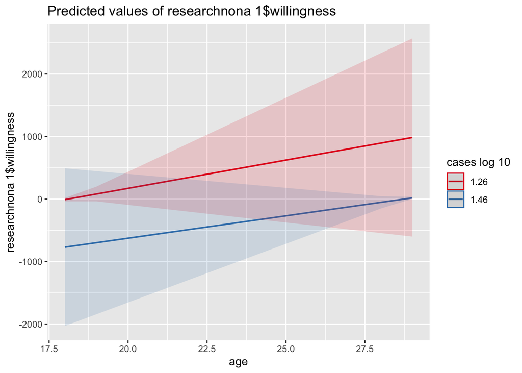

```r
library(sjPlot)
plot_model(cases_interaction, type = "int") #type = "int" to plot marginal effects of interaction terms in a more convenient way.
```

# 14 The relationship between health situation with reserved character in different ages

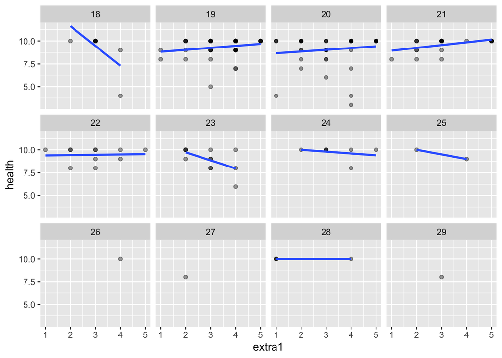

```r
ggplot(researchnona1,
       aes(x = extra1, y = health)) +
  geom_point(alpha = 0.4) +
  geom_smooth(method = "lm", se = FALSE) +
  facet_wrap(~age)
```

At age 18 and 23, the reserved character has more effect on health situation, at other ages, seems quite plain

#15 Willingness to get a covid19 vaccination between genders

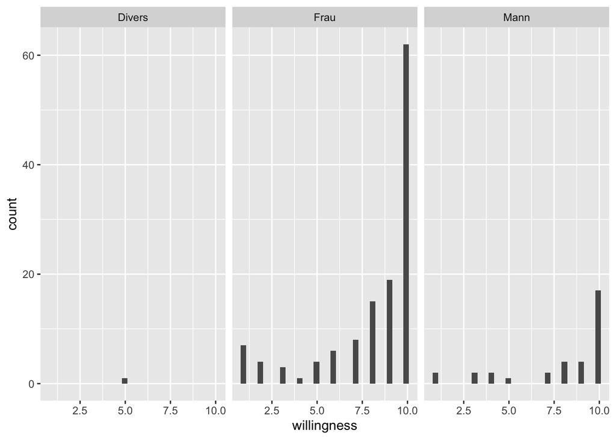

```r
ggplot(research,
       aes(x = willingness))+geom_histogram() + facet_wrap(~sex)
```

we can see either girls or boys have more people willing to get a covid19 vaccination